# EECE_Project

Nikhil_Maddikunta

December 14, 2017

```r
library(ggplot2)
library(forecast)
library(tseries)
library(readxl)
library(lubridate)
```

# Loading the data of 2014 and 2015

```r
elec_train <- read_excel("Full Data.xlsx", sheet = "Training")
elec_train$Transaction_Dates <- elec_train$Transaction_Dates + hours(elec_train$Hours)
```

# Histogram of Price Variable

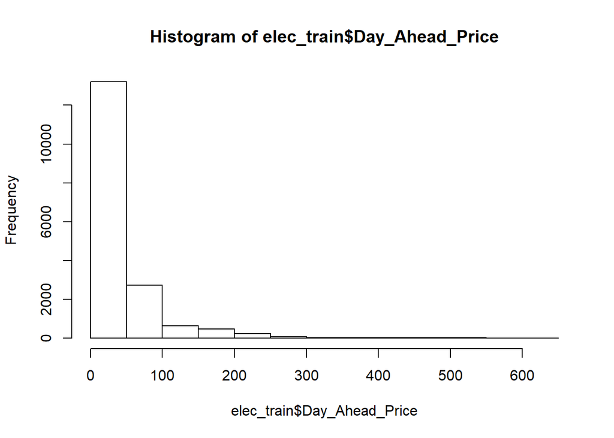

```r
hist(elec_train$Day_Ahead_Price)
```

#The data is right Skewed. We can apply logarithm to bring to normalize #Applying log function and plotting histogram

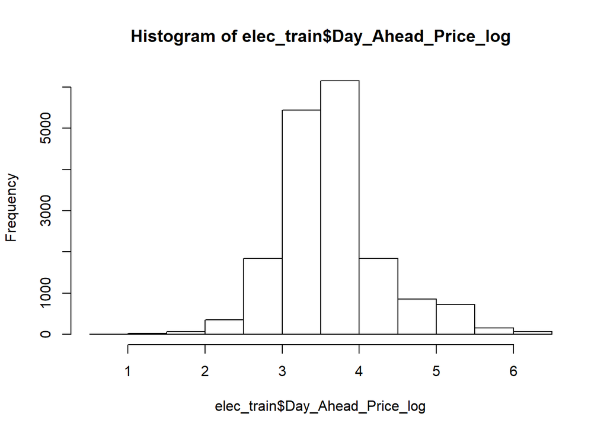

```r
elec_train$Day_Ahead_Price_log <- log(elec_train$Day_Ahead_Price)
hist(elec_train$Day_Ahead_Price_log)
```

#Convert the price variable to time series object

```r
elec_train$Day_Ahead_Price_ts <- ts(elec_train$Day_Ahead_Price_log)
```

# Cleaning the variable to removing any outliers present. Forcast function has tsclean function which removes outlier and missing values

```r
elec_train$Day_Ahead_Price_ts <- tsclean(elec_train$Day_Ahead_Price_ts)
```

# Plotting the price variable

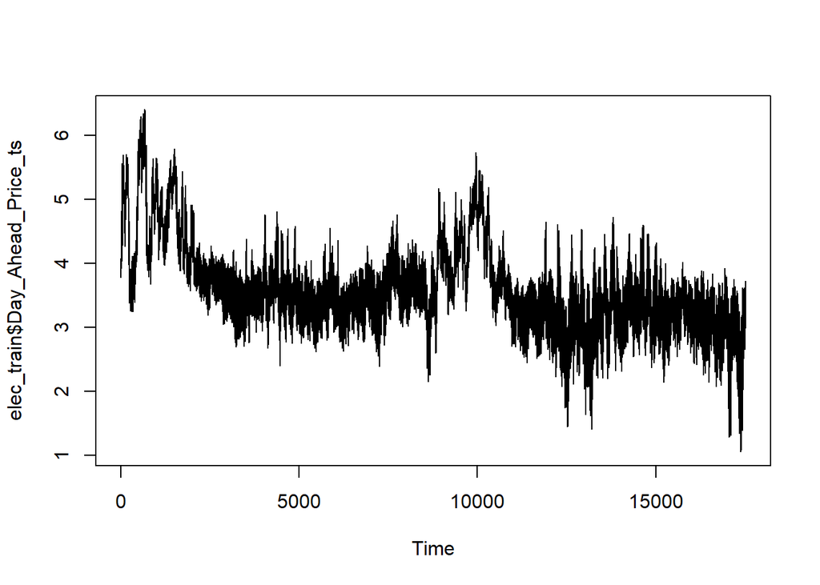

```r
plot(elec_train$Day_Ahead_Price_ts)
```

#The data is a 2 year data. We see that there is a sesonality present at the beginning of the year with high price. The data is pretty volatile as we see there are peaks and troughs. So we need to apply smoothing to noise out those fluctuations.

# Checking the stationarity of the data

```r
adf.test(elec_train$Day_Ahead_Price_ts, alternative = "stationary")
```

```
##
##  Augmented Dickey-Fuller Test
##
## data:  elec_train$Day_Ahead_Price_ts
## Dickey-Fuller = -7.4966, Lag order = 25, p-value = 0.01
## alternative hypothesis: stationary
```

# Here the alternate hypothesis is the data is stationary. The P value is less than 0.05. we conclude that the we have stationary data.

# Plotting ACF and PACF of the data to see autocorrelation present.

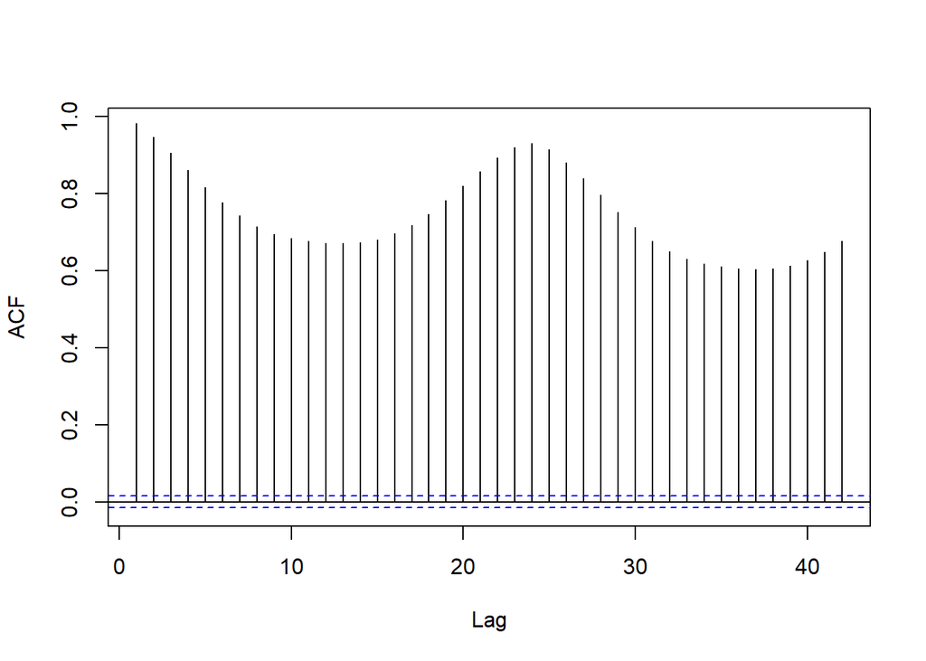

```r
Acf(elec_train$Day_Ahead_Price_ts, main='')
```

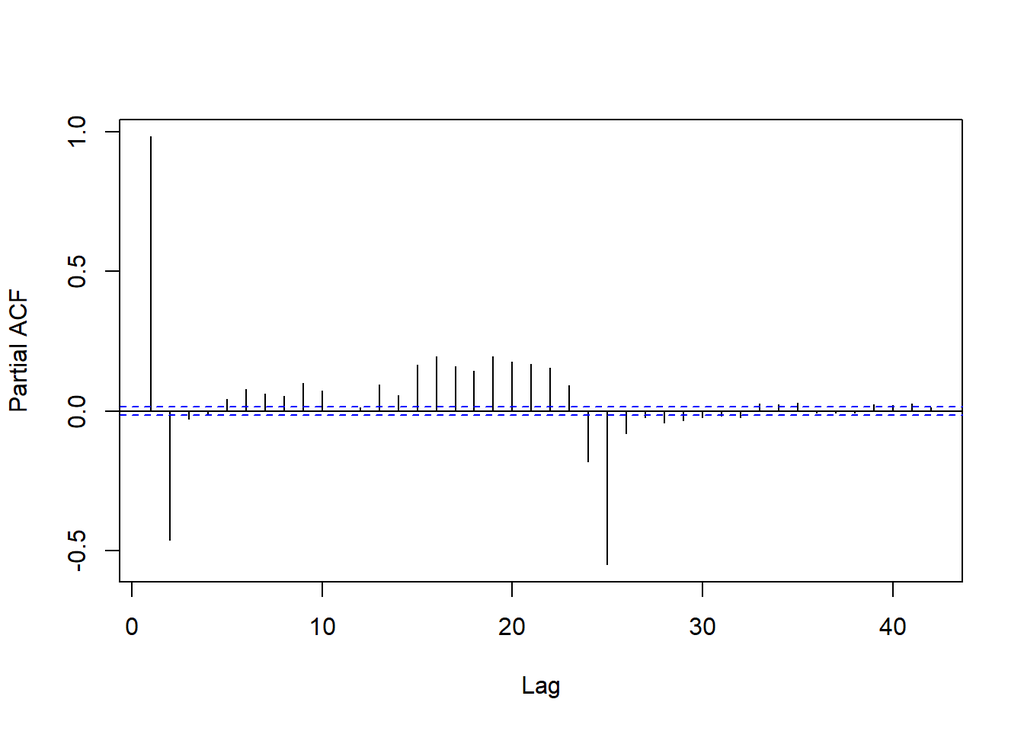

```r
Pacf(elec_train$Day_Ahead_Price_ts, main='')
```

#The Significance level is 0.05. We see the lags have high correlation values. This suggest that the data is highly autocorrelated. Also we see higher autocorelation at 24 lag . This indicates that at the end and start of the day the data is highly correlated with its previous values.

# The PACF value also reflects the same.

# Visually, we could a draw a line through the series tracing its bigger troughs and peaks while smoothing out noisy fluctuations. This line can be described by one of the simplest - but also very useful -concepts in time series analysis known as a moving average

# Daily and weekly moving average is applied to the data.

```r
elec_train$ma_1 <- ma(elec_train$Day_Ahead_Price_ts, order = 24)
elec_train$ma_2 <- ma(elec_train$Day_Ahead_Price_ts, order = 168)
```

# Plotting both weekly and daily moving averages

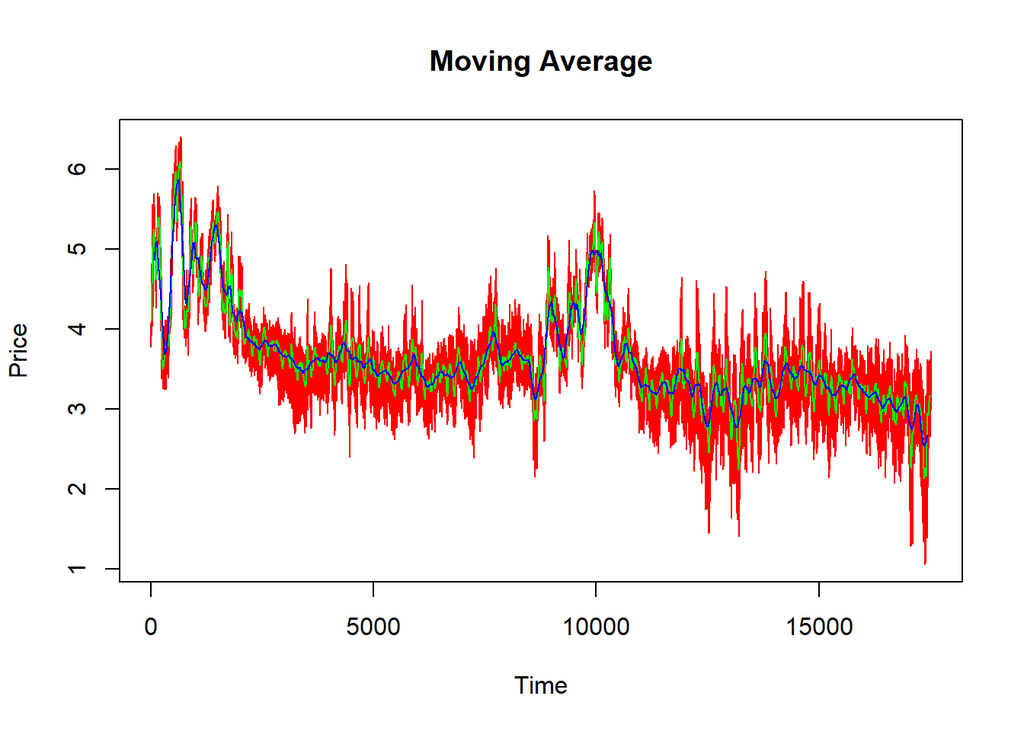

```r
plot(elec_train$Day_Ahead_Price_ts, col = "red", main = "Moving Average", xlab = "Time", ylab = "Price")
lines(elec_train$ma_1, col="green")
lines(elec_train$ma_2, col="blue")
```

#Red line represent original series. Green Daily averages. Blue weekly averages #To apply ARIMA we need three component. AR component, differencing component and moving average component. we need to find out a combination that fits the data from ACF and PACF plots. But we have function in forcast package called auto.arima which find these components.

```r
ar.fit2 <- auto.arima(elec_train$Day_Ahead_Price, seasonal = TRUE)
summary(ar.fit2)
```

```
## Series: elec_train$Day_Ahead_Price
## ARIMA(4,1,3)
##
## Coefficients:
##          ar1      ar2     ar3      ar4      ma1     ma2      ma3
##       1.4728  -0.8752  0.3575  -0.1479  -1.2399  0.5277  -0.1920
## s.e.  0.0833   0.1123  0.0632   0.0197   0.0841  0.0961   0.0438
##
## sigma^2 estimated as 69.68:  log likelihood=-62029.57
## AIC=124075.1   AICc=124075.1   BIC=124137.3
##
## Training set error measures:
##                        ME     RMSE      MAE       MPE     MAPE      MASE
## Training set -0.003486234 8.345472 4.062835 -1.442158 8.412234 0.8956841
##                       ACF1
## Training set -0.0009779424
```

```r
ar.f3 <- forecast(ar.fit2, h = 24)
ar.fitted3 <- data.frame(as.numeric(ar.fit2$fitted))
ar.predict3 <- data.frame(as.numeric(ar.f3$mean))
elec_test <- read_excel("Full Data.xlsx", sheet = "Test")
elec_test_1 <- elec_test[1:24,]
ModelMetrics::rmse(elec_test_1$Day_Ahead_Price,ar.predict3[,1])
```

```
## [1] 7.54139
```

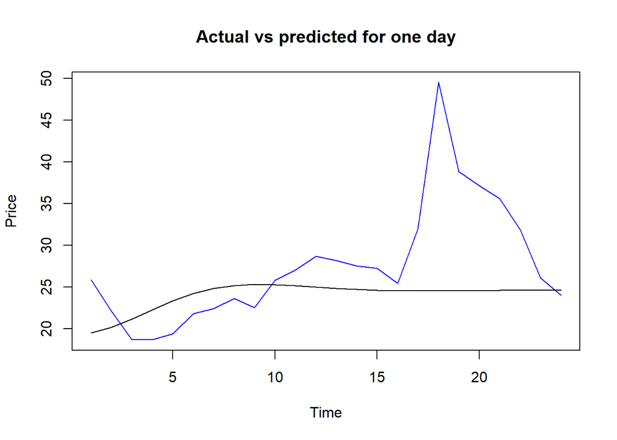

```r
plot(ts(elec_test_1$Day_Ahead_Price), col="blue", main = "Actual vs predicted for one day", xlab = "Time", ylab = "Price")
lines(ts(ar.predict3[,1]))
```

#The RMSE value for one day is 7.5413. The graph shows the actual and predicted data for day ahead.

# From the summary we see that arima components are 4,1,3. we can use this model to predict the 2016 data. In 2016 data we have 8762 records to be predicted.

```r
ar.f2 <- forecast(ar.fit2, h=8762)
ar.fitted2 <- data.frame(as.numeric(ar.fit2$fitted))
ar.predict2 <- data.frame(as.numeric(ar.f2$mean))
```

# Calculating the RMSE of the training data and the validation data.

```r
ModelMetrics::rmse(elec_train$Day_Ahead_Price,ar.fitted2[,1])
```

```
## [1] 8.345472
```

```r
elec_test <- read_excel("Full Data.xlsx", sheet = "Test")
ModelMetrics::rmse(elec_test$Day_Ahead_Price,ar.predict2[,1])
```

```
## [1] 14.91415
```